# Conventions for handling negative response values: simulation results

## The study

We simulated concentration-response data from a four-parameter curve (`nec4param`) in which specific growth rate falls from a positive control value to a negative lower asymptote, and we handed each simulated dataset to six analyses that differ only in how they treat the negative values. Every analysis uses `bayesnec` with package defaults, model-averaged over the declining candidate set the family allows, so a difference between arms is the difference a practitioner would obtain rather than a likelihood-only contrast.

**Table 1.** The six conventions compared. All six are reachable from `bnec()` defaults.

| arm | what the analyst does | family |
| --- | --- | --- |
| measured | use the values as recorded | gaussian |
| censored | declare negatives left-censored at zero | gaussian |
| deleted | delete the negative rows, keep the rest of their group | gaussian |
| floored | replace negatives with zero | gaussian |
| beta | floor, scale to (0, 1), fit a Beta | Beta |
| gamma | floor, fit a Gamma | Gamma |

Seven design cells were run, each 100 times. Four vary measurement precision alone, holding the design and the true values fixed, so that the control coefficient of variation falls from 9.6% to 1.9%. Two vary the depth of the lower asymptote. One stops the concentration series at the point where the true curve reaches zero growth, so that almost nothing is negative and the conventions have nothing to act on.

The true values are known by construction, so each analysis is scored against them rather than against each other. We report relative bias, the proportion of 95% credible intervals containing the truth, and the mean interval width.

## Estimating ErC50

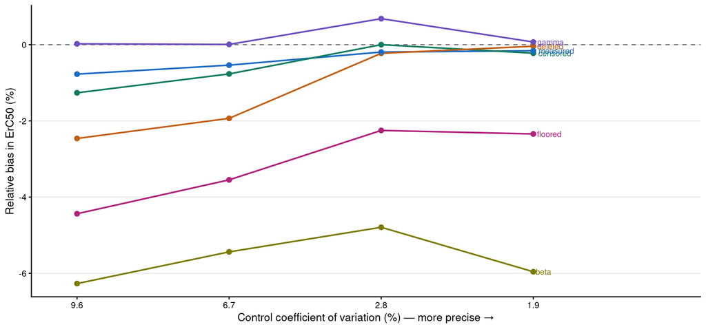

Figure 1

Three arms converge as the experiment improves: `measured` from -0.8% to -0.2%, `censored` from -1.3% to -0.2%, and `deleted` from -2.5% to 0.0%. Their error is estimation error, and it behaves like estimation error.

## Estimating ErC10

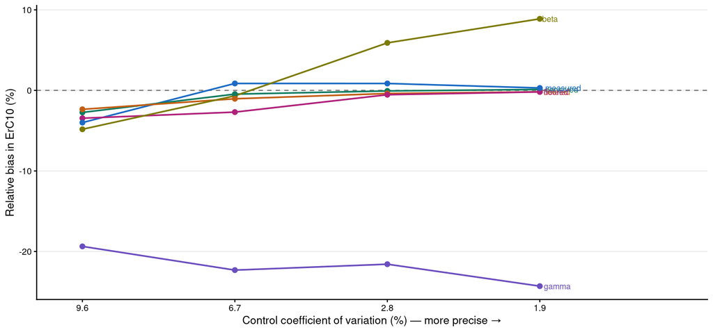

Figure 2

**Figure 2.** Relative bias in the estimated ErC10. `gamma` is displaced by about 20% at every level of precision.

The four Gaussian arms are within a few per cent of the truth once the measurement is precise enough to resolve a 10% decline, and they converge. `gamma` does not: it underestimates ErC10 by 19% to 24% in every cell of the precision axis, and the error is flat, so a better experiment does not help. `beta` drifts the other way, from -4.8% to +8.9%.

ErC10 is the harder estimate for every arm at realistic noise, because a 10% decline from the control has to be resolved against a control coefficient of variation of 9.6%. That is a property of the endpoint rather than of any convention, and it is why the precision axis is necessary to interpret it.

## The NSEC

The no-significant-effect concentration is where the conventions diverge most, and where they diverge in a direction that matters for protection.

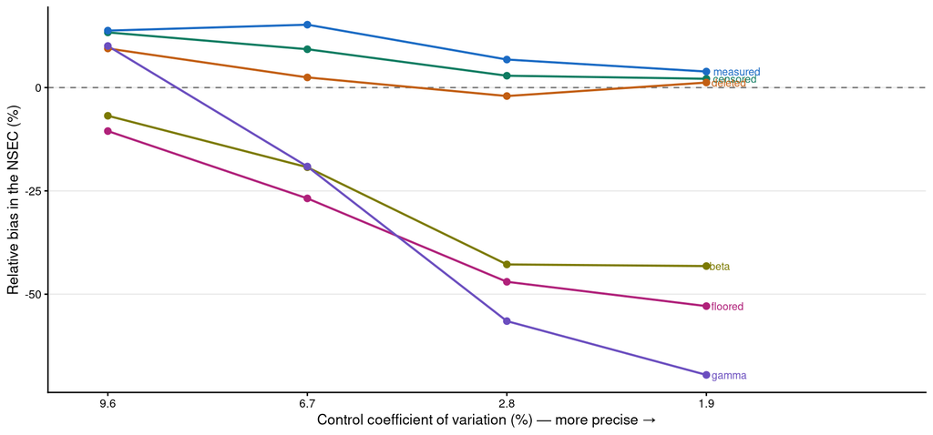

Figure 3

**Figure 3.** Relative bias in the estimated NSEC against the true no-effect concentration. The three arms that keep the measurement converge toward it from above; the three that replace it diverge downward as precision improves.

The NSEC’s expected value exceeds the true `nec` at any finite level of noise, because it is defined against a lower quantile of the control posterior: a noisier control gives a lower reference and pushes the crossing to the right. Its limiting value as the residual error goes to zero is the true `nec`, which is why the precision axis is the only way to read it.

The arms that keep the measurement behave as that definition predicts. `measured` falls from +13.8% to +3.9%, `censored` from +13.4% to +2.1% and `deleted` from +9.5% to +1.2%, all approaching the truth from above.

The arms that replace it go the other way and keep going. `floored` moves from -10.5% to -52.9%, `beta` from -6.8% to -43.2%, and `gamma` from +10.1% to -69.5%. Improving the experiment makes these three worse, and at the highest precision tested they place the no-effect concentration between two and three times too low.

## Interval coverage

Bias understates the problem, because the intervals narrow around a displaced centre as the experiment improves.

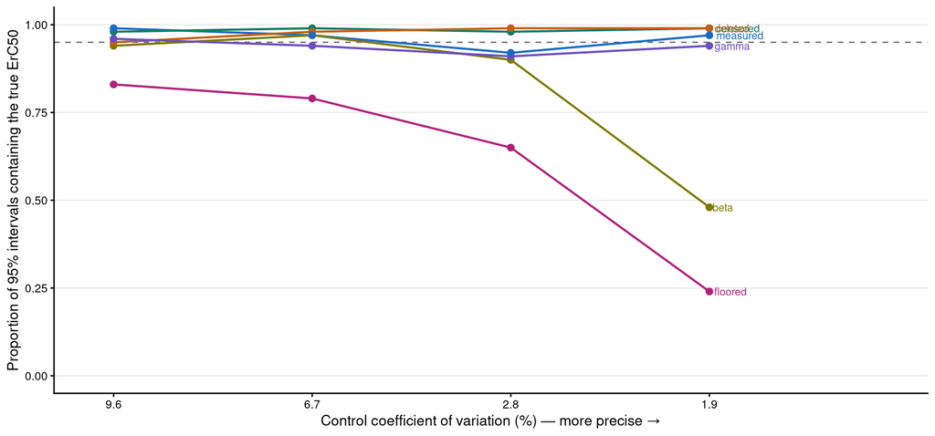

Figure 4

**Table 2.** ErC50 at the two ends of the precision axis. Coverage and interval width are reported together, because either alone identifies the wrong arm as the best one.

| cell | arm | bias (%) | coverage | mean width | RMSE |
| --- | --- | --- | --- | --- | --- |
| CV 1.9% | measured | -0.16 | 0.97 | 0.134 | 0.031 |
| CV 1.9% | censored | -0.22 | 0.99 | 0.271 | 0.064 |
| CV 1.9% | deleted | -0.04 | 0.99 | 0.300 | 0.075 |
| CV 1.9% | floored | -2.34 | 0.24 | 0.198 | 0.124 |
| CV 1.9% | beta | -5.96 | 0.48 | 0.549 | 0.305 |
| CV 1.9% | gamma | 0.07 | 0.94 | 0.296 | 0.103 |
| CV 9.6% | measured | -0.77 | 0.99 | 0.981 | 0.185 |
| CV 9.6% | censored | -1.26 | 0.98 | 0.922 | 0.198 |
| CV 9.6% | deleted | -2.46 | 0.95 | 1.038 | 0.270 |
| CV 9.6% | floored | -4.44 | 0.83 | 0.861 | 0.316 |
| CV 9.6% | beta | -6.27 | 0.94 | 1.451 | 0.381 |
| CV 9.6% | gamma | 0.02 | 0.96 | 2.123 | 0.347 |

At the highest precision tested, `floored` contains the true ErC50 in 24 of 100 intervals and `beta` in 48, against a nominal 95. Their bias at that point is only -2.3% and -6.0%; it is the narrowing of the interval around a displaced centre that destroys the coverage.

A laboratory that improves its technique, adds replicates and reduces its control variability will, if it replaces its negative values, obtain an analysis that is more confident and no more accurate.

Coverage and width have to be read together. `gamma` reaches 0.94 coverage at the highest precision, which looks respectable until its mean interval width of 0.296 is compared with `measured`’s 0.134, and its ErC10 bias of -24% is recalled. Either statistic alone identifies the wrong arm as the best one.

## Where the response barely goes negative

**Table 3.** The control cell, in which the concentration series stops where the true curve reaches zero growth, so that almost no true mean is negative.

| estimate | arm | bias (%) | coverage |
| --- | --- | --- | --- |
| ErC50 | measured | -1.11 | 0.99 |
| ErC50 | censored | -1.28 | 0.98 |
| ErC50 | deleted | -0.17 | 0.97 |
| ErC50 | floored | -0.68 | 0.99 |
| ErC50 | beta | -3.20 | 0.99 |
| ErC50 | gamma | -4.47 | 0.98 |
| NSEC | measured | 9.90 | 0.97 |
| NSEC | censored | 9.54 | 0.96 |
| NSEC | deleted | 6.24 | 1.00 |
| NSEC | floored | 6.90 | 0.99 |
| NSEC | beta | -18.95 | 1.00 |
| NSEC | gamma | 81.65 | 0.95 |

Where the design does not reach the zero-growth boundary, the four Gaussian arms agree to within about two per cent on ErC50 and the conventions have nothing to act on. The two family-imposed arms still differ, because scaling to a proportion or fitting a Gamma changes the analysis whether or not any value is negative.

This is the condition under which none of the results above apply. Reporting the proportion of observations at or below zero is what tells a reader which situation they are in.

## What the study establishes

The measurement should be kept. `measured` is unbiased to within one per cent on ErC50 at every level of precision tested, converges on the truth for all three estimates, and holds nominal coverage.

Where the negative values were never recorded, censoring recovers almost all of what replacing them loses: `censored` tracks `measured` to within about half a percentage point on ErC50 across the precision axis.

Deleting the negative rows is better than replacing them with zero but worse than either alternative above, and it discards information that censoring retains.

Replacing negative values with zero biases ErC50 low, places the NSEC two to three times too low at high precision, and drives interval coverage to 0.24. The error does not shrink as the experiment improves.

## Provenance

The study is 4,200 model-averaged fits: seven cells, six arms, 100 iterations, each fit averaging over the declining candidate set for its family. It ran on the AIMS HPC as a SLURM array, one unit per task, with zero failures. Peak memory was 1.93 GB per unit and the mean unit took 936 seconds.

`bayesnec` was pinned at commit `0976caca`, version 2.1.3.33, from the `dev` branch. That is not the CRAN release: the current CRAN version is 2.1.3.1, which does not include the change peaking the `nec` and `ec50` gamma prior at the median predictor rather than at twice it. The priors are therefore a development default rather than a released one, and the exact values used are committed as 42 files in `priors/`, one per cell and arm.

Those priors are held fixed within a cell and arm rather than being derived from each realisation. `bayesnec` derives its defaults from the response vector and `brms` writes them into the Stan source as literals, so a prior that varies by realisation makes every fit a distinct Stan program: 5,622 compiles for 406 units before this was changed. Fixing them makes the program identical across iterations. The predictor range is identical across realisations within a cell and arm, so the hard parameter bounds do not vary at all; only the response-derived scales would have, by a few per cent. Each arm keeps its own prior, derived from its own prepared data, so the contrast between arms is unaffected.

The generating model is carried over verbatim from open-AIMS/negative-sgr at commit `0181d66e`. Nothing else is.